# Assignment

Use the "from the expert" (FTE) jupyter notebook as a starter for this assignment, and ask your instructor questions if you need help.

Use the `churn_data.csv` file to carry out a similar EDA and visualization process as what we did in the FTE. Create at least 2 EDA plots, and create a HTML file with an auto-EDA analysis using pandas-profiling or another auto-EDA Python package. Write a short analysis at the end of the assignment in markdown.

## Data science process steps this week

We will carry out the first two parts of the CRISP-DM data science process this week:

1. Business understanding

This is customer churn data for a telecommunications company. Customers can have phone as well as other services. The company is looking to reduce customer churn, where customers stop using the company's services and cancel their account. The 'Churn' column has a binary target, yes or no, that denotes if a customer churned. We want to create a machine learning model to predict the Churn target using the other available data in the dataset. Ideally, we will deploy this model to integrate with the company's database, so that a churn risk column is created for each customer. This will enable customer service reps and others to devise and use strategies to reduce churn.

1. Data understanding

Carry out some EDA as we did in the FTE, such as using pandas-profiling. Create a histogram like we did in the FTE, where we plot a numeric column with the target as the 'hue'. Optional challenge: create other plots with the target as the hue, such as bar plots for the categorical columns.

```python
!conda install -c conda-forge pandas pandas-profiling matplotlib openpyxl -y
```

```
Solving environment: done

# All requested packages already installed.
```

```python
import pandas as pd
from pandas_profiling import ProfileReport
import matplotlib.pyplot as plt
```

```python
# we can give our index column a number or name but its's optional.
df = pd.read_csv('/Users/dikshyaupreti/downloads/churn_data.csv')
df
```

|  | customerID | tenure | PhoneService | Contract | PaymentMethod | MonthlyCharges | TotalCharges | Churn |
| --- | --- | --- | --- | --- | --- | --- | --- | --- |
| 0 | 7590-VHVEG | 1 | No | Month-to-month | Electronic check | 29.85 | 29.85 | No |
| 1 | 5575-GNVDE | 34 | Yes | One year | Mailed check | 56.95 | 1889.50 | No |
| 2 | 3668-QPYBK | 2 | Yes | Month-to-month | Mailed check | 53.85 | 108.15 | Yes |
| 3 | 7795-CFOCW | 45 | No | One year | Bank transfer (automatic) | 42.30 | 1840.75 | No |
| 4 | 9237-HQITU | 2 | Yes | Month-to-month | Electronic check | 70.70 | 151.65 | Yes |
| ... | ... | ... | ... | ... | ... | ... | ... | ... |
| 7038 | 6840-RESVB | 24 | Yes | One year | Mailed check | 84.80 | 1990.50 | No |
| 7039 | 2234-XADUH | 72 | Yes | One year | Credit card (automatic) | 103.20 | 7362.90 | No |
| 7040 | 4801-JZAZL | 11 | No | Month-to-month | Electronic check | 29.60 | 346.45 | No |
| 7041 | 8361-LTMKD | 4 | Yes | Month-to-month | Mailed check | 74.40 | 306.60 | Yes |
| 7042 | 3186-AJIEK | 66 | Yes | Two year | Bank transfer (automatic) | 105.65 | 6844.50 | No |

7043 rows × 8 columns

```python
df.head()
```

|  | customerID | tenure | PhoneService | Contract | PaymentMethod | MonthlyCharges | TotalCharges | Churn |
| --- | --- | --- | --- | --- | --- | --- | --- | --- |
| 0 | 7590-VHVEG | 1 | No | Month-to-month | Electronic check | 29.85 | 29.85 | No |
| 1 | 5575-GNVDE | 34 | Yes | One year | Mailed check | 56.95 | 1889.50 | No |
| 2 | 3668-QPYBK | 2 | Yes | Month-to-month | Mailed check | 53.85 | 108.15 | Yes |
| 3 | 7795-CFOCW | 45 | No | One year | Bank transfer (automatic) | 42.30 | 1840.75 | No |
| 4 | 9237-HQITU | 2 | Yes | Month-to-month | Electronic check | 70.70 | 151.65 | Yes |

```python
df.tail()
```

|  | customerID | tenure | PhoneService | Contract | PaymentMethod | MonthlyCharges | TotalCharges | Churn |
| --- | --- | --- | --- | --- | --- | --- | --- | --- |
| 7038 | 6840-RESVB | 24 | Yes | One year | Mailed check | 84.80 | 1990.50 | No |
| 7039 | 2234-XADUH | 72 | Yes | One year | Credit card (automatic) | 103.20 | 7362.90 | No |
| 7040 | 4801-JZAZL | 11 | No | Month-to-month | Electronic check | 29.60 | 346.45 | No |
| 7041 | 8361-LTMKD | 4 | Yes | Month-to-month | Mailed check | 74.40 | 306.60 | Yes |
| 7042 | 3186-AJIEK | 66 | Yes | Two year | Bank transfer (automatic) | 105.65 | 6844.50 | No |

```python
# use the argument minimal=True to speed this up, although you won't get all the plots and stats
report = ProfileReport(df)
report.to_file('churn_data.html')
```

```python
df.info()
```

```
<class 'pandas.core.frame.DataFrame'>
RangeIndex: 7043 entries, 0 to 7042
Data columns (total 8 columns):
 #   Column          Non-Null Count  Dtype
---  ------          --------------  -----
 0   customerID      7043 non-null   object
 1   tenure          7043 non-null   int64
 2   PhoneService    7043 non-null   object
 3   Contract        7043 non-null   object
 4   PaymentMethod   7043 non-null   object
 5   MonthlyCharges  7043 non-null   float64
 6   TotalCharges    7032 non-null   float64
 7   Churn           7043 non-null   object
dtypes: float64(2), int64(1), object(5)
memory usage: 440.3+ KB
```

```python
df.describe()
```

|  | tenure | MonthlyCharges | TotalCharges |
| --- | --- | --- | --- |
| count | 7043.000000 | 7043.000000 | 7032.000000 |
| mean | 32.371149 | 64.761692 | 2283.300441 |
| std | 24.559481 | 30.090047 | 2266.771362 |
| min | 0.000000 | 18.250000 | 18.800000 |
| 25% | 9.000000 | 35.500000 | 401.450000 |
| 50% | 29.000000 | 70.350000 | 1397.475000 |
| 75% | 55.000000 | 89.850000 | 3794.737500 |
| max | 72.000000 | 118.750000 | 8684.800000 |

```python
df.columns
```

```
Index(['customerID', 'tenure', 'PhoneService', 'Contract', 'PaymentMethod',
       'MonthlyCharges', 'TotalCharges', 'Churn'],
      dtype='object')
```

```python
# select a column and get the counts of each unique value
df['Contract'].value_counts()
```

```
Month-to-month    3875
Two year          1695
One year          1473
Name: Contract, dtype: int64
```

```python
df['Contract'].unique()
```

```
array(['Month-to-month', 'One year', 'Two year'], dtype=object)
```

Exploratory data analysis :Using the telecom data provided ,I was able to do a analysis on the customer's trend and was able to closely understand various factors that were resposible for the customer's choices and decisions.The factors I evaluated were customer's contract type,tenure and the total charges they were billed.

```python
pip install matplotlib
```

```python
import matplotlib.pyplot as plt
import numpy as np
%matplotlib inline
```

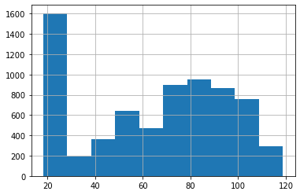

```python
df['MonthlyCharges'].hist()
```

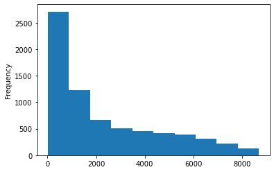

```python
df['TotalCharges'].plot.hist()
```

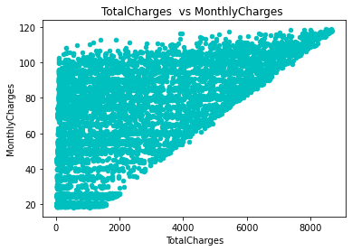

```python
df.plot.scatter(x='TotalCharges',y='MonthlyCharges',title = 'TotalCharges  vs MonthlyCharges ',color= 'c')
```

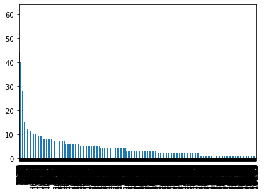

```python
df['MonthlyCharges'].value_counts().plot.bar()
```

[figure not shown]

```python
df['MonthlyCharges'].value_counts() [:20].plot.bar()
plt.xlabel('MonthlyCharges')
plt.ylabel('Counts')
```

```python
!conda install -c conda-forge seaborn phik -y
```

[output not shown]

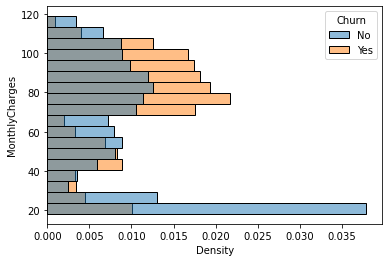

```python
import phik
import seaborn as sns

_ = sns.histplot(data=df, y='MonthlyCharges', hue='Churn', stat='density', common_norm=False)
```

Exploratory data analysis :Using the telecom data provided,I was able to do a analysis on customer's trend and was to closely understand various factors that wereresponsible for customer's choices and decisions.The factors I evaluated were using customer's Total and Monthly Charges.The diagram above shows that cutomer's monthly charges arevery crucial in decision making while choosing the data provider.In this case also people with higher charges seem to be more likely to churn.